# Администрирование локальных сетей

Лабораторная работа №5

Авдадаев Джамал Геланиевич

Российский университет дружбы народов, Москва, Россия

# Цели и задачи работы

## Цель лабораторной работы

Получить основные навыки по настройке VLAN на коммутаторах сети, изучить конфигурирование Trunk-портов, VTP, статической адресации и проверить сетевую связность в Cisco Packet Tracer.

# Ход выполнения работы

## Построение топологии сети

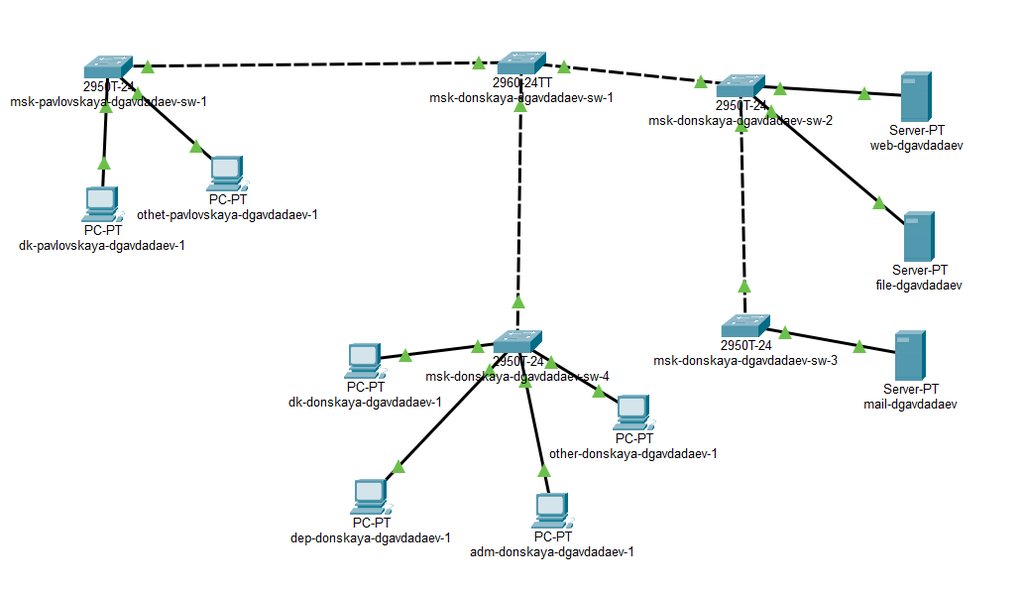

Топология сети в Packet Tracer

## Настройка VTP-сервера и создание VLAN

На коммутаторе msk-donskaya-dgavadadev-sw-1 был настроен режим VTP Server.  
Также были созданы VLAN:

- VLAN 2 — management
- VLAN 3 — servers
- VLAN 101 — dk
- VLAN 102 — departments
- VLAN 103 — adm
- VLAN 104 — other

## Настройка VTP-сервера и создание VLAN

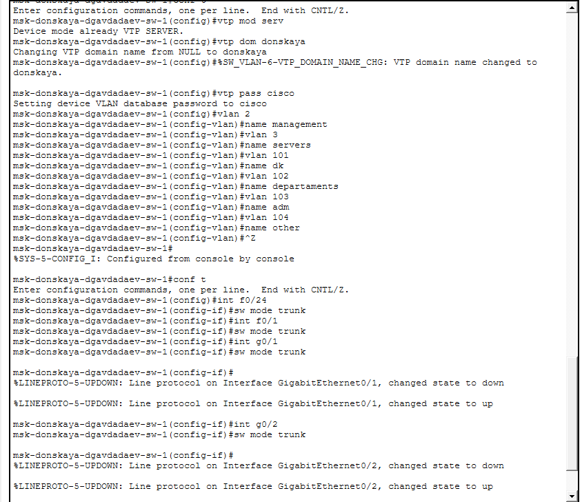

Настройка VTP-сервера и VLAN

## Настройка коммутатора msk-donskaya-dgavadadev-sw-2

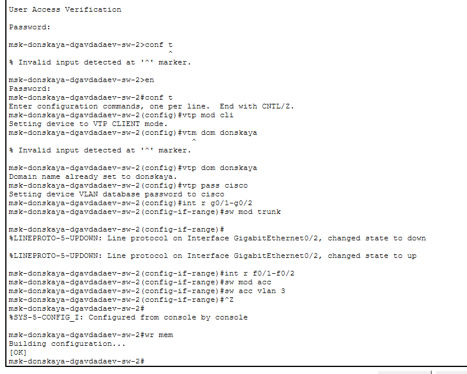

Настройка коммутатора sw-2

## Настройка коммутатора msk-donskaya-dgavadadev-sw-3

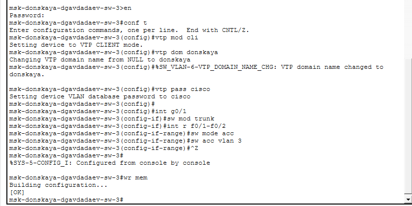

Настройка коммутатора sw-3

## Настройка коммутатора msk-donskaya-dgavadadev-sw-4

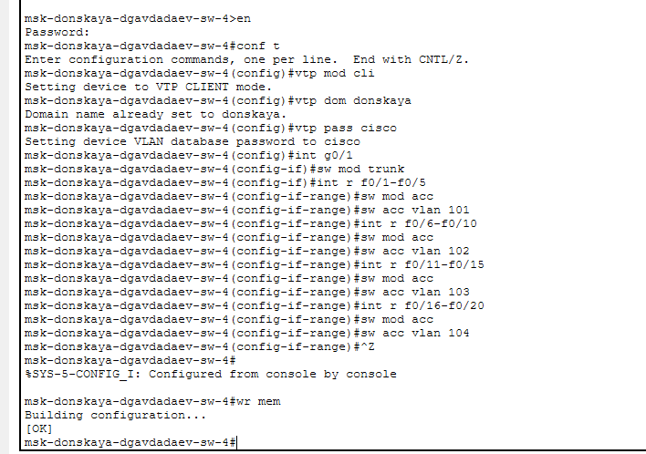

## Настройка коммутатора msk-pavlovskaya-dgavadadev-sw-1

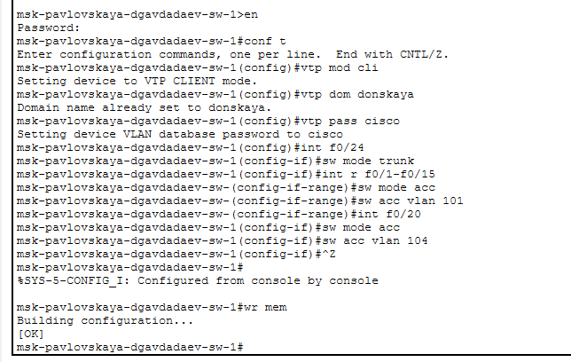

Настройка коммутатора pavlovskaya-sw-1

## Настройка IP-адресов серверов

На серверах были заданы статические IP-адреса из сети 10.128.0.0/24:

- web-dgavadadev — 10.128.0.2
- file-dgavadadev — 10.128.0.3
- mail-dgavadadev — 10.128.0.4
- шлюз по умолчанию — 10.128.0.1

## Настройка IP-адресов оконечных устройств

Рабочим станциям были назначены статические IP-адреса из диапазонов соответствующих VLAN с указанием шлюза по умолчанию.

Примеры настроенных адресов: - dk-donskaya-dgavadadev-1 — 10.128.3.5 - dk-pavlovskaya-dgavadadev-1 — 10.128.3.15 - dep-donskaya-dgavadadev-1 — 10.128.4.5 - adm-donskaya-dgavadadev-1 — 10.128.5.5 - other-donskaya-dgavadadev-1 — 10.128.6.5 - othet-pavlovskaya-dgavadadev-1 — 10.128.6.15

## Проверка связности с помощью ping

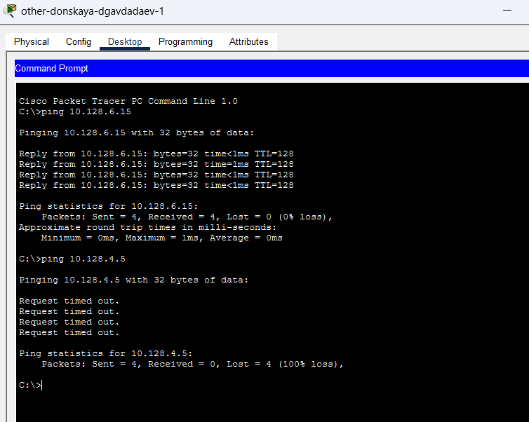

## Проверка связности с помощью ping

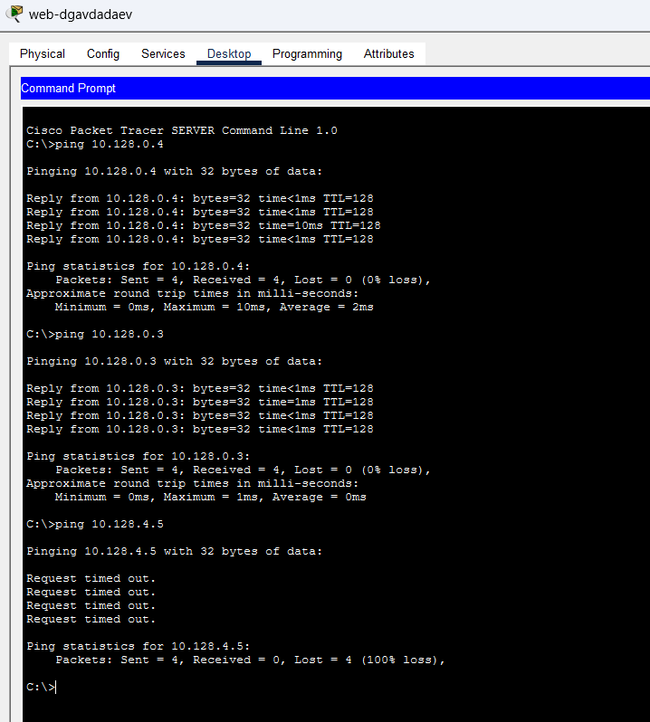

Проверка связи между серверами

## Анализ ICMP-пакета в режиме Simulation

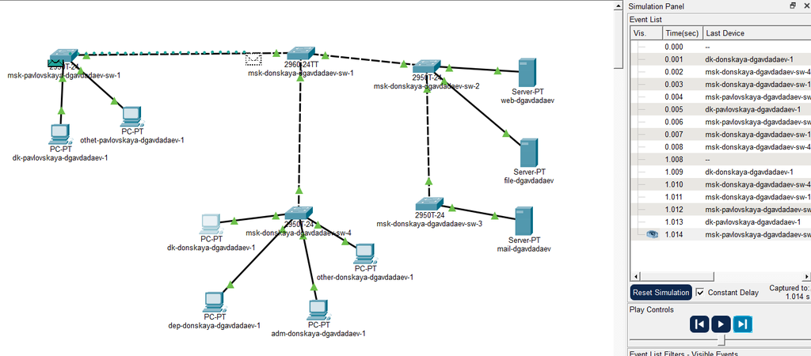

## Анализ ICMP-пакета в режиме Simulation

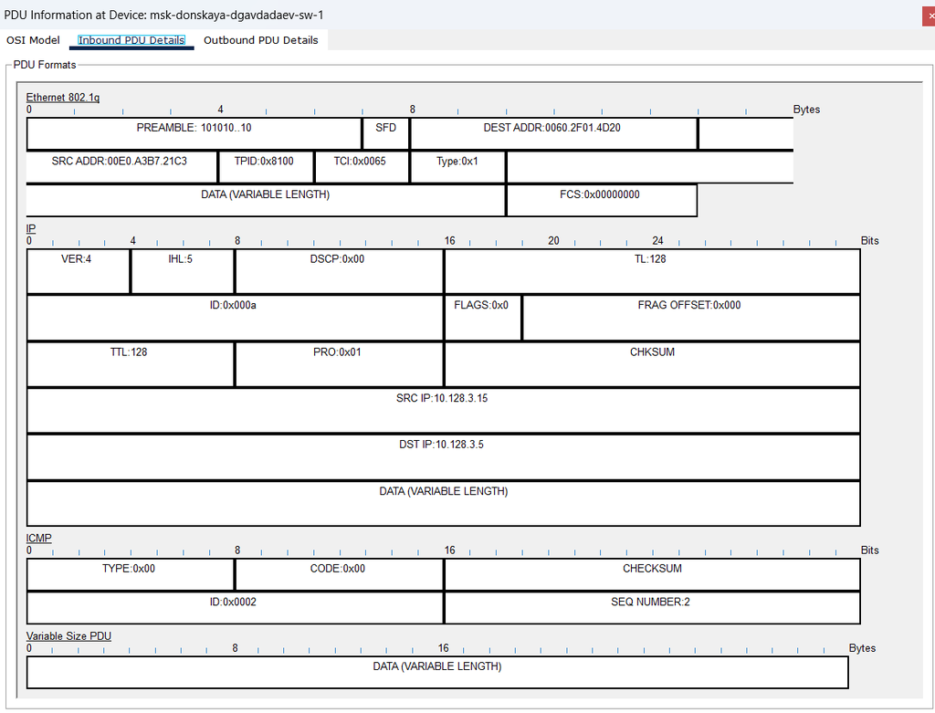

Структура ICMP пакета

# Выводы

## Итог лабораторной работы

В ходе выполнения лабораторной работы была построена топология сети в Cisco Packet Tracer и выполнена настройка коммутаторов с использованием протокола VTP. На коммутаторе msk-donskaya-dgavadadev-sw-1 был настроен режим VTP-сервера и созданы необходимые VLAN, после чего остальные коммутаторы были настроены в режиме VTP-клиентов и автоматически получили конфигурацию VLAN.

Также были настроены магистральные соединения между коммутаторами с использованием Trunk-портов и выполнено распределение пользовательских портов по соответствующим VLAN. На серверах и оконечных устройствах были заданы статические IP-адреса и настроены шлюзы по умолчанию.

После завершения настройки была выполнена проверка сетевой связности с помощью команды ping. Проверка показала доступность устройств внутри одного VLAN и недоступность устройств, принадлежащих различным VLAN, что подтверждает корректную работу сегментации сети.